Consider the fossil data again.

### 1. Display and study the scatterplot of these data. What features of the data look interesting to you? Do this before answering the other questions.

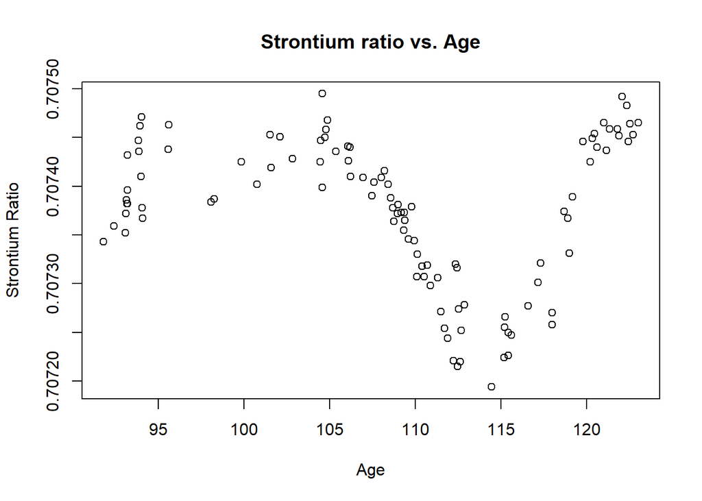

```r
set.seed(4428967)
setwd("~/tamu/MS-STAT-2022/689-flexible-regression")
fossil = read.csv("fossil.csv")
plot(fossil$Age, fossil$Strontium.Ratio
     , main="Strontium ratio vs. Age"
     , xlab="Age"
     , ylab="Strontium Ratio")
```

The interesting features of the data are:

1. The clear non-linear relationship between Age and Strontium ratio
2. Need for 3 piece-wise regressions: (90-105), (105-112.5) and (112.5-123)
3. Some heteroskedasticity with strontium ratio showing greater variance for lower values of age.

### 2. Fit the fossil data using the default version of smooth.spline.a. Get and save the model object. You use something like myspline = smooth.spline(…). The model object is myspline. b. Add the fitted line to the scatter plot of the data and display the resulting plot.

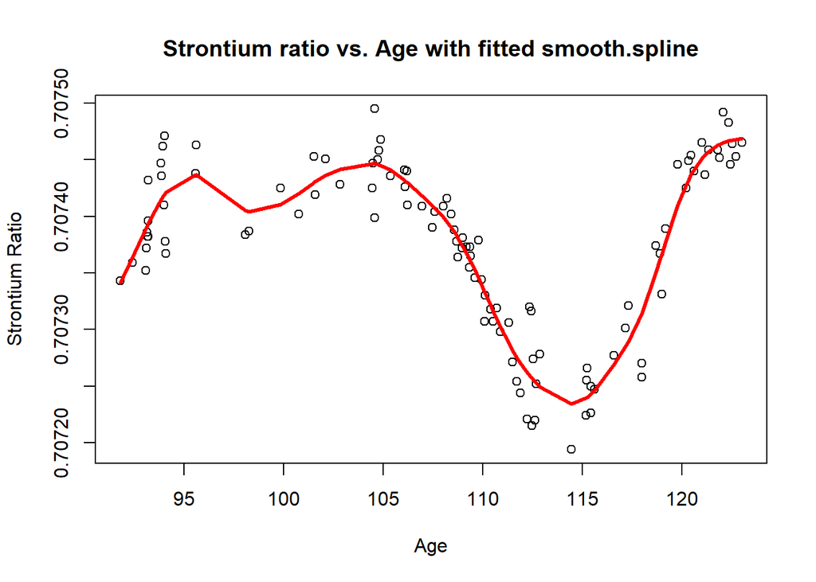

```r
myspline = smooth.spline(x=fossil$Age, y=fossil$Strontium.Ratio)
mypred = predict(myspline)
plot(fossil$Age, fossil$Strontium.Ratio
     , main="Strontium ratio vs. Age with fitted smooth.spline"
     , xlab="Age"
     , ylab="Strontium Ratio")
lines(mypred$x,mypred$y,lwd=3,col="red")
```

### 3. Run the mgcv fit to the data with the default number of knots (K=8) and with both K = 4 and K = 23 knots and using the cubic spline option as I have done. Save the model fit objects, e.g., gam4, gam8 and gam23

```r
library(mgcv)
#using K+2 to be consistent with our notation
gam4 = mgcv::gam(Strontium.Ratio~s(Age, k=6,bs="cr"), data=fossil)
gam8 = mgcv::gam(Strontium.Ratio~s(Age, k=10,bs="cr"), data=fossil)
gam23 = mgcv::gam(Strontium.Ratio~s(Age, k=25,bs="cr"), data=fossil)
```

### 3a. Which fits are statistically significant? Be sure to quote the p-values for all three.

```r
summary(gam4)
```

```
##
## Family: gaussian
## Link function: identity
##
## Formula:
## Strontium.Ratio ~ s(Age, k = 6, bs = "cr")
##
## Parametric coefficients:
##              Estimate Std. Error t value Pr(>|t|)
## (Intercept) 7.074e-01  2.921e-06  242135   <2e-16 ***
## ---
## Signif. codes:  0 '***' 0.001 '**' 0.01 '*' 0.05 '.' 0.1 ' ' 1
##
## Approximate significance of smooth terms:
##          edf Ref.df     F p-value
## s(Age) 4.954  4.999 114.1  <2e-16 ***
## ---
## Signif. codes:  0 '***' 0.001 '**' 0.01 '*' 0.05 '.' 0.1 ' ' 1
##
## R-sq.(adj) =  0.844   Deviance explained = 85.1%
## GCV = 9.585e-10  Scale est. = 9.0466e-10  n = 106
```

```r
summary(gam8)
```

```
##
## Family: gaussian
## Link function: identity
##
## Formula:
## Strontium.Ratio ~ s(Age, k = 10, bs = "cr")
##
## Parametric coefficients:
##              Estimate Std. Error t value Pr(>|t|)
## (Intercept) 7.074e-01  2.549e-06  277472   <2e-16 ***
## ---
## Signif. codes:  0 '***' 0.001 '**' 0.01 '*' 0.05 '.' 0.1 ' ' 1
##
## Approximate significance of smooth terms:
##         edf Ref.df     F p-value
## s(Age) 8.06   8.72 89.01  <2e-16 ***
## ---
## Signif. codes:  0 '***' 0.001 '**' 0.01 '*' 0.05 '.' 0.1 ' ' 1
##
## R-sq.(adj) =  0.881   Deviance explained =   89%
## GCV = 7.533e-10  Scale est. = 6.8892e-10  n = 106
```

```r
summary(gam23)
```

```
##
## Family: gaussian
## Link function: identity
##
## Formula:
## Strontium.Ratio ~ s(Age, k = 25, bs = "cr")
##
## Parametric coefficients:
##              Estimate Std. Error t value Pr(>|t|)
## (Intercept) 7.074e-01  2.441e-06  289812   <2e-16 ***
## ---
## Signif. codes:  0 '***' 0.001 '**' 0.01 '*' 0.05 '.' 0.1 ' ' 1
##
## Approximate significance of smooth terms:
##          edf Ref.df     F p-value
## s(Age) 11.56  13.89 61.71  <2e-16 ***
## ---
## Signif. codes:  0 '***' 0.001 '**' 0.01 '*' 0.05 '.' 0.1 ' ' 1
##
## R-sq.(adj) =  0.891   Deviance explained = 90.3%
## GCV = 7.1639e-10  Scale est. = 6.315e-10  n = 106
```

The intercept and smooth terms are highly statistically significant at alpha=0.05 for all three GAMs. All of their p-values are <2e-16

### 3b. Plot the fits with the data points on one graph ONLY and submit that graph.

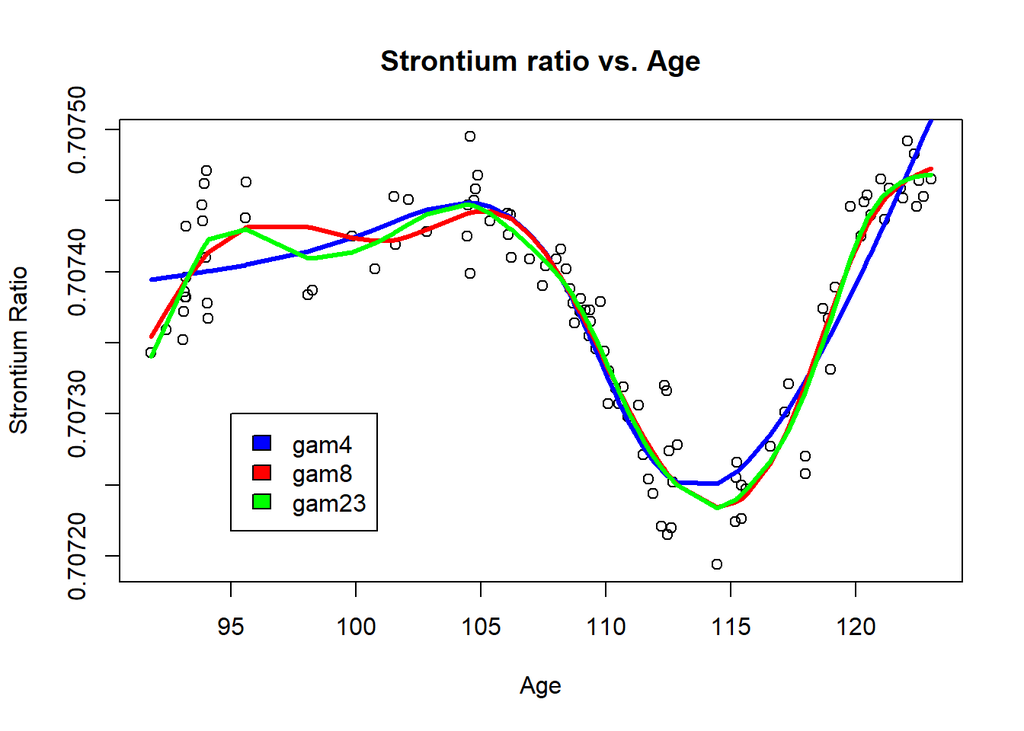

```r
plot(fossil$Age, fossil$Strontium.Ratio
     , main="Strontium ratio vs. Age"
     , xlab="Age"
     , ylab="Strontium Ratio")
ord <- order(fossil$Age)
lines(fossil$Age[ord], fitted(gam4)[ord], lwd=3, col="blue")
lines(fossil$Age[ord], fitted(gam8)[ord], lwd=3, col="red")
lines(fossil$Age[ord], fitted(gam23)[ord], lwd=3, col="green")
legend(95, 0.70730, legend=c("gam4", "gam8", "gam23"),fill = c("blue","red", "green"))
```

### 3c. Do the fits agree more or less with your answer to Question 1? Why or why not?

Yes, the fits agree. The main observations in question 1 were non-linearity of data and the need of piece-wise regressions between (90-105), (105-112.5) and (112.5-123). All the 3 gams in the plot above show a similar kind of fit with piece-wise regressions and are non-linear.

### 4. What are the effective degrees of freedom for each mgcv fit?

```r
sum(gam4$edf)-1
```

```
## [1] 4.953819
```

```r
sum(gam8$edf)-1
```

```
## [1] 8.060309
```

```r
sum(gam23$edf)-1
```

```
## [1] 11.56099
```

effective degree of freedom for gam4 is 4.953819

effective degree of freedom for gam8 is 8.060309

effective degree of freedom for gam23 is 11.56099

### 5. What is lambda for each fit?

```r
gam4$sp
```

```
##   s(Age)
## 0.211446
```

```r
gam8$sp
```

```
##   s(Age)
## 1.823264
```

```r
gam23$sp
```

```
##   s(Age)
## 24.29164
```

lambda for gam4 is 0.211446.

lambda for gam8 is 1.823264.

lambda for gam23 is 24.29164.

### 6. Tell me whether or not the p-value for each choice of K is < 0.10. Cite those p-values. If any are < 0.10, then explain intuitively from your graphs why that number of basis functions is inadequate.

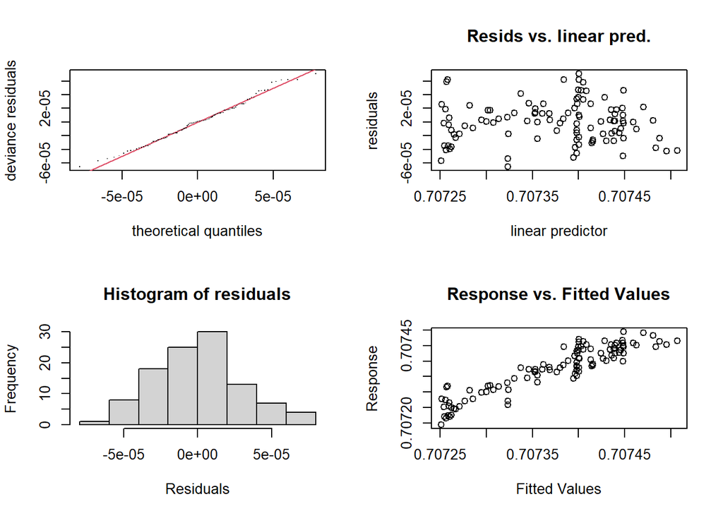

```
##
## Method: GCV   Optimizer: magic
## Smoothing parameter selection converged after 4 iterations.
## The RMS GCV score gradient at convergence was 4.873853e-11 .
## The Hessian was positive definite.
## Model rank =  6 / 6
##
## Basis dimension (k) checking results. Low p-value (k-index<1) may
## indicate that k is too low, especially if edf is close to k'.
##
##          k'  edf k-index p-value
## s(Age) 5.00 4.95    0.73  <2e-16 ***
## ---
## Signif. codes:  0 '***' 0.001 '**' 0.01 '*' 0.05 '.' 0.1 ' ' 1
```

```r
gam.check(gam4)
```

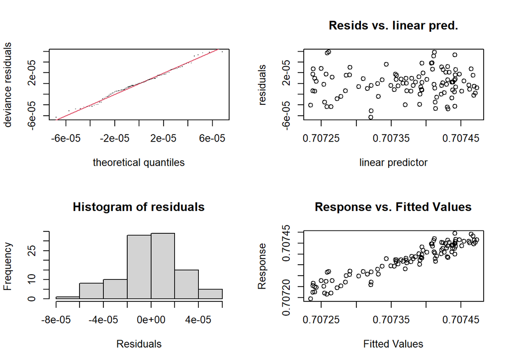

```
##
## Method: GCV   Optimizer: magic
## Smoothing parameter selection converged after 4 iterations.
## The RMS GCV score gradient at convergence was 3.767214e-12 .
## The Hessian was positive definite.
## Model rank =  10 / 10
##
## Basis dimension (k) checking results. Low p-value (k-index<1) may
## indicate that k is too low, especially if edf is close to k'.
##
##          k'  edf k-index p-value
## s(Age) 9.00 8.06    0.95    0.28
```

```r
gam.check(gam8)
```

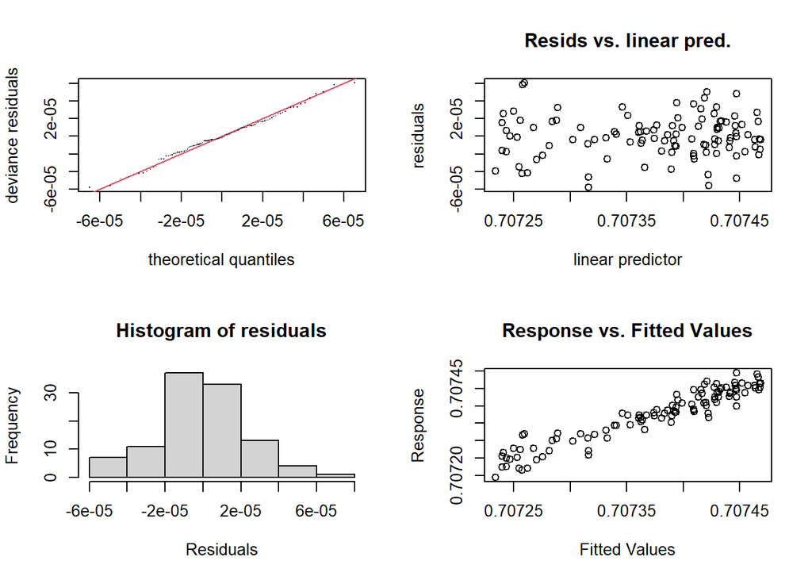

```
##
## Method: GCV   Optimizer: magic
## Smoothing parameter selection converged after 4 iterations.
## The RMS GCV score gradient at convergence was 3.310986e-14 .
## The Hessian was positive definite.
## Model rank =  25 / 25
##
## Basis dimension (k) checking results. Low p-value (k-index<1) may
## indicate that k is too low, especially if edf is close to k'.
##
##          k'  edf k-index p-value
## s(Age) 24.0 11.6    1.05    0.64
```

```r
gam.check(gam23)
```

p-value for gam4 is <2e-16 (less than 0.10)

p-value for gam8 is 0.28

p-value for gam23 is 0.64

P-value for gam4 is < 0.10 while for gam8 and gam23 is > 0.10.

Looking at the scatterplot it seems gam4 is not able to capture the smaller fluctuations in the data which gam23 and gam8 are able to capture. Therefore, number of basis function are inadequate for gam4.